# Notebook

## Data Pre-processing

### Outlier Check

```
Outliers in no_of_employees: 1556
```

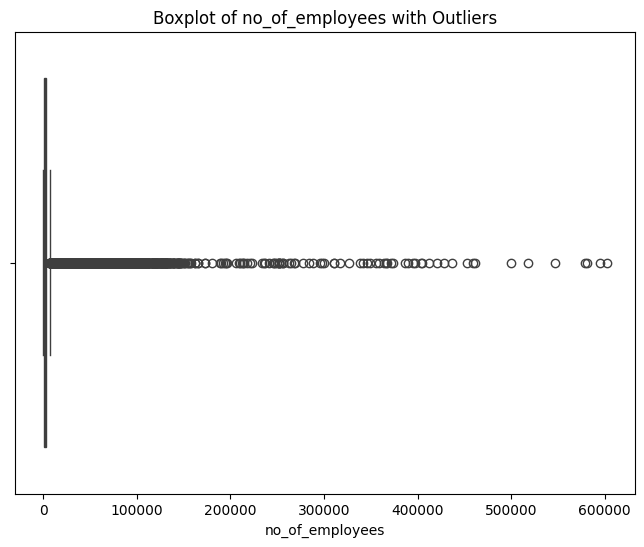

```
Outliers in yr_of_estab: 3259
```

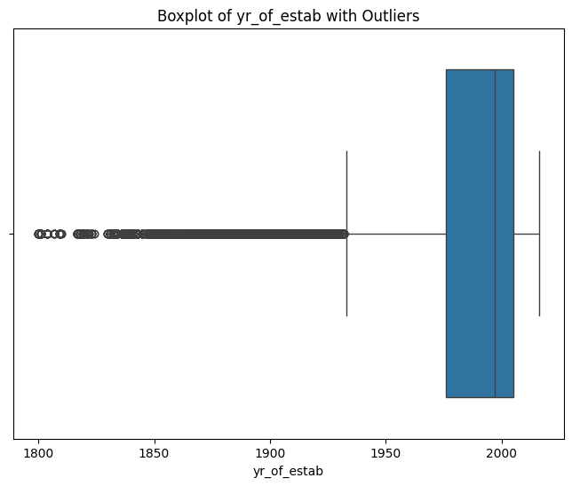

```
Outliers in prevailing_wage: 427
```

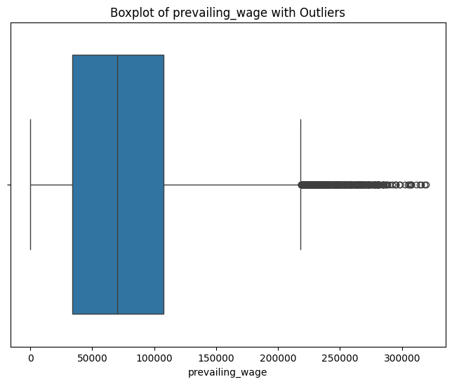

```python
import matplotlib.pyplot as plt
import seaborn as sns
import numpy as np

# Function to detect outliers using IQR method
def detect_outliers_iqr(data, feature):
    Q1 = data[feature].quantile(0.25)
    Q3 = data[feature].quantile(0.75)
    IQR = Q3 - Q1
    lower_bound = Q1 - 1.5 * IQR
    upper_bound = Q3 + 1.5 * IQR
    outliers = data[(data[feature] < lower_bound) | (data[feature] > upper_bound)]
    print(f"Outliers in {feature}: {len(outliers)}")

    # Plotting the boxplot to visualize the outliers
    plt.figure(figsize=(8, 6))
    sns.boxplot(x=data[feature])
    plt.title(f'Boxplot of {feature} with Outliers')
    plt.show()

    return outliers

# Apply this function to all numerical columns
numerical_columns = data.select_dtypes(include=np.number).columns

for col in numerical_columns:
    detect_outliers_iqr(data, col)
```

```python
# Check missing values
missing_values = data.isnull().sum()
print(missing_values[missing_values > 0])
```

```
Series([], dtype: int64)
```

### Data Preparation for modeling

```python
from sklearn.preprocessing import LabelEncoder
import pandas as pd

# Define mapping for ordinal columns
education_mapping = {"High School": 0, "Bachelor's": 1, "Master's": 2, "Doctorate": 3}
wage_mapping = {"Hour": 0, "Week": 1, "Month": 2, "Year": 3}

# Define the binary columns that need Label Encoding
binary_cols = ["has_job_experience", "requires_job_training", "full_time_position"]

# Define the ordinal columns that need manual mapping
ordinal_cols = ["education_of_employee", "unit_of_wage"]

# Define the nominal columns for One-Hot Encoding
nominal_cols = ["continent", "region_of_employment"]

# Initialize LabelEncoder
label_encoder = LabelEncoder()

# 1. Retain the case_id column and exclude it from encoding
case_id = data['case_id']

# Drop the case_id temporarily for transformations
data = data.drop(columns=['case_id'])

# 2. Label Encoding for Binary Features (Y/N to 1/0)
for col in binary_cols:
    if col in data.columns:
        data[col] = label_encoder.fit_transform(data[col])

# 3. Ordinal Encoding for Ordinal Features
# Map the education and wage columns
data["education_of_employee"] = data["education_of_employee"].map(education_mapping)
data["unit_of_wage"] = data["unit_of_wage"].map(wage_mapping)

# 4. One-Hot Encoding for Nominal Features (creating dummy variables for continents and regions)
data = pd.get_dummies(data, columns=nominal_cols, drop_first=True)

# 5. Re-add the case_id column back to the dataset without any encoding
data['case_id'] = case_id

# 6. Label Encoding for the target variable (case_status)
#data['case_status'] = label_encoder.fit_transform(data['case_status'])

# Check the first few rows to verify the transformations
print("Transformed Data:")
print(data.head())

# Check the final columns after transformation
print("\nColumns after encoding:")
print(data.columns)
```

```
Transformed Data:
   education_of_employee  has_job_experience  requires_job_training  \
0                      0                   0                      0
1                      2                   1                      0
2                      1                   0                      1
3                      1                   0                      0
4                      2                   1                      0

   no_of_employees  yr_of_estab  prevailing_wage  unit_of_wage  \
0            14513         2007         592.2029             0
1             2412         2002       83425.6500             3
2            44444         2008      122996.8600             3
3               98         1897       83434.0300             3
4             1082         2005      149907.3900             3

   full_time_position case_status  continent_Asia  continent_Europe  \
0                   1      Denied            True             False
1                   1   Certified            True             False
2                   1      Denied            True             False
3                   1      Denied            True             False
4                   1   Certified           False             False

   continent_North America  continent_Oceania  continent_South America  \
0                    False              False                    False
1                    False              False                    False
2                    False              False                    False
3                    False              False                    False
4                    False              False                    False

   region_of_employment_Midwest  region_of_employment_Northeast  \
0                         False                           False
1                         False                            True
2                         False                           False
3                         False                           False
4                         False                           False

   region_of_employment_South  region_of_employment_West case_id
0                       False                       True  EZYV01
1                       False                      False  EZYV02
2                       False                       True  EZYV03
3                       False                       True  EZYV04
4                        True                      False  EZYV05

Columns after encoding:
Index(['education_of_employee', 'has_job_experience', 'requires_job_training',
       'no_of_employees', 'yr_of_estab', 'prevailing_wage', 'unit_of_wage',
       'full_time_position', 'case_status', 'continent_Asia',
       'continent_Europe', 'continent_North America', 'continent_Oceania',
       'continent_South America', 'region_of_employment_Midwest',
       'region_of_employment_Northeast', 'region_of_employment_South',
       'region_of_employment_West', 'case_id'],
      dtype='object')
```

```python
data.shape
```

```
(25447, 19)
```

## Model Building

### Model Evaluation Criterion

```python
# defining a function to compute different metrics to check performance of a classification model built using sklearn
# Import necessary modules
from sklearn.metrics import accuracy_score, recall_score, precision_score, f1_score
import pandas as pd

def model_performance_classification_sklearn(model, predictors, target):
    """
    Function to compute different metrics to check classification model performance

    model: classifier
    predictors: independent variables
    target: dependent variable
    """

    # Predicting using the independent variables
    pred = model.predict(predictors)

    # Calculate metrics
    acc = accuracy_score(target, pred)  # Accuracy
    recall = recall_score(target, pred, average='binary')  # Recall, with 'binary' as default for binary classification
    precision = precision_score(target, pred, average='binary')  # Precision
    f1 = f1_score(target, pred, average='binary')  # F1-score

    # Creating a dataframe to return the metrics
    df_perf = pd.DataFrame(
        {"Accuracy": [acc], "Recall": [recall], "Precision": [precision], "F1": [f1]},
        index=[0],
    )

    return df_perf


def model_performance_classification_sklearn(model, predictors, target):
    """
    Function to compute different metrics to check classification model performance

    model: classifier
    predictors: independent variables
    target: dependent variable
    """

    # predicting using the independent variables
    pred = model.predict(predictors)

    acc = accuracy_score(target, pred)  # to compute Accuracy
    recall = recall_score(target, pred)  # to compute Recall
    precision = precision_score(target, pred)  # to compute Precision
    f1 = f1_score(target, pred)  # to compute F1-score

    # creating a dataframe of metrics
    df_perf = pd.DataFrame(
        {"Accuracy": acc, "Recall": recall, "Precision": precision, "F1": f1,},
        index=[0],
    )

    return df_perf
```

```python
def confusion_matrix_sklearn(model, predictors, target):
    """
    To plot the confusion_matrix with percentages

    model: classifier
    predictors: independent variables
    target: dependent variable
    """
    y_pred = model.predict(predictors)
    cm = confusion_matrix(target, y_pred)
    labels = np.asarray(
        [
            ["{0:0.0f}".format(item) + "\n{0:.2%}".format(item / cm.flatten().sum())]
            for item in cm.flatten()
        ]
    ).reshape(2, 2)

    plt.figure(figsize=(6, 4))
    sns.heatmap(cm, annot=labels, fmt="")
    plt.ylabel("True label")
    plt.xlabel("Predicted label")
```

#### Defining scorer to be used for cross-validation and hyperparameter tuning

Since our objective is to **predict visa approval (certified/denied)** based on different attributes, we need to decide the best evaluation metric. Let's analyze:

1. **Problem Type** This is a binary classification problem, where:

Negative class: Denied (visa not approved)

2. **Business Impact of Errors** We must consider the cost of misclassification:

**False Positive (FP):** Predicting a visa will be approved when it gets denied → bad for the applicant

**False Negative (FN):** Predicting a visa will be denied when it actually gets approved → bad for the employer

Since we don’t want to reject potentially eligible candidates, we should minimize False Negatives (FN) and **maximize Recall**.

**Recall** is more important since we want to identify all possible approvals correctly.

```
case_status
Certified    66.809447
Denied       33.190553
Name: proportion, dtype: float64
```

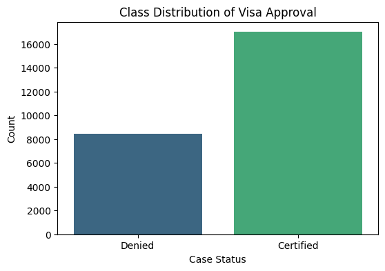

```python
# Checking class distribution
import matplotlib.pyplot as plt
import seaborn as sns

# Count the values of case_status
print(data["case_status"].value_counts(normalize=True) * 100)  # Percentage distribution

# Plot the class distribution
plt.figure(figsize=(6, 4))
sns.countplot(x=data["case_status"], palette="viridis")
plt.title("Class Distribution of Visa Approval")
plt.xlabel("Case Status")
plt.ylabel("Count")
plt.show()
```

**We are now done with pre-processing and evaluation criterion, so let's start building the model.**

```python
from sklearn.model_selection import train_test_split
from sklearn.preprocessing import LabelEncoder

# Encode 'case_status'
label_encoder = LabelEncoder()
data["case_status"] = label_encoder.fit_transform(data["case_status"])  # 'Certified' -> 1, 'Denied' -> 0

# Split data into predictors and target variable
X = data.drop(columns=["case_id", "case_status"])  # dropping case_id and target variable
y = data["case_status"]

# First split: Data into temporary (80%) and test (20%) sets
X_temp, X_test, y_temp, y_test = train_test_split(X, y, test_size=0.2, random_state=42, stratify=y)

# Second split: Temporary set into training (80%) and validation (20%) sets
X_train, X_val, y_train, y_val = train_test_split(X_temp, y_temp, test_size=0.2, random_state=42, stratify=y_temp)

# Check the shapes of the resulting sets
print(f"X_train shape: {X_train.shape}, X_val shape: {X_val.shape}, X_test shape: {X_test.shape}")
```

```
X_train shape: (16285, 17), X_val shape: (4072, 17), X_test shape: (5090, 17)
```

### Model building with original data

```
Training Performance:
   Accuracy  Recall  Precision   F1
0       1.0     1.0        1.0  1.0
Validation Performance:
   Accuracy   Recall  Precision        F1
0  0.651277  0.47929   0.475073  0.477172
Test Performance:
   Accuracy    Recall  Precision        F1
0   0.64833  0.473653   0.470312  0.471976
```

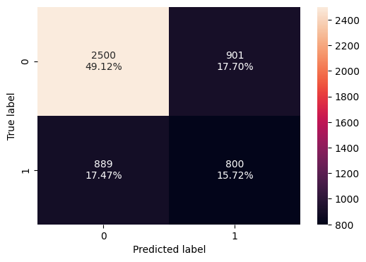

```python
# Initialize Decision Tree Classifier model
from sklearn.tree import DecisionTreeClassifier

# Initialize the model with random_state for reproducibility
model_original = DecisionTreeClassifier(random_state=42)

# Train the model on the training set
model_original.fit(X_train, y_train)

# Predict using the training set
y_train_pred = model_original.predict(X_train)

# Evaluate the model performance on the training set
model_performance_train_original = model_performance_classification_sklearn(model_original, X_train, y_train)

# Print the training performance metrics
print("Training Performance:")
print(model_performance_train_original)

# Predict using the validation set
y_val_pred = model_original.predict(X_val)

# Evaluate the model performance on the validation set
model_performance_val_original = model_performance_classification_sklearn(model_original, X_val, y_val)

# Print the validation performance metrics
print("Validation Performance:")
print(model_performance_val_original)

# Predict using the test set (final evaluation)
y_test_pred = model_original.predict(X_test)

# Evaluate the model performance on the test set
model_performance_test_original = model_performance_classification_sklearn(model_original, X_test, y_test)

# Print the final test performance metrics
print("Test Performance:")
print(model_performance_test_original)

# Call the existing confusion matrix function to plot on the test set
confusion_matrix_sklearn(model_original, X_test, y_test)
```

### Model Building with oversampled data

```
Model Performance on Training Set:
   Accuracy  Recall  Precision   F1
0       1.0     1.0        1.0  1.0
Model Performance on Validation Set:
   Accuracy    Recall  Precision        F1
0   0.65275  0.508136   0.478412  0.492826
Model Performance on Test Set:
   Accuracy    Recall  Precision        F1
0  0.659528  0.505625   0.487443  0.496367
```

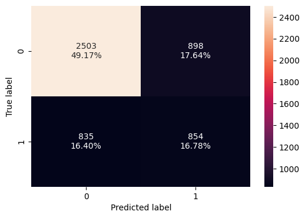

```python
# Apply SMOTE to oversample the minority class in the training data
from imblearn.over_sampling import SMOTE
from sklearn.tree import DecisionTreeClassifier

# Apply SMOTE to balance the classes in the training data
smote = SMOTE(random_state=42)
X_train_smote, y_train_smote = smote.fit_resample(X_train, y_train)

# Initialize the model (Decision Tree, for simplicity)
model_oversampled = DecisionTreeClassifier(random_state=42)

# Train the model with oversampled data
model_oversampled.fit(X_train_smote, y_train_smote)

# Predict using the training set
y_train_pred = model_oversampled.predict(X_train_smote)

# Evaluate the model performance on the training set
model_performance_train_smote = model_performance_classification_sklearn(model_oversampled, X_train_smote, y_train_smote)

# Print the training performance metrics
print("Model Performance on Training Set:")
print(model_performance_train_smote)

# Predict using the validation set to check how well the model is performing on unseen data
y_val_pred = model_oversampled.predict(X_val)

# Evaluate the model performance on the validation set
model_performance_val_smote = model_performance_classification_sklearn(model_oversampled, X_val, y_val)

# Print the validation performance metrics
print("Model Performance on Validation Set:")
print(model_performance_val_smote)

# Predict using the test set for final evaluation
y_test_pred = model_oversampled.predict(X_test)

# Evaluate the model performance on the test set
model_performance_test_smote = model_performance_classification_sklearn(model_oversampled, X_test, y_test)

# Print the final test performance metrics
print("Model Performance on Test Set:")
print(model_performance_test_smote)

# Call the confusion matrix function for the test set
confusion_matrix_sklearn(model_oversampled, X_test, y_test)
```

### Model Building with undersampled data

```
Model Performance on Training Set (Undersampled Data):
   Accuracy  Recall  Precision   F1
0       1.0     1.0        1.0  1.0
Model Performance on Validation Set (Undersampled Data):
   Accuracy    Recall  Precision        F1
0  0.626965  0.635355   0.455703  0.530738
Model Performance on Test Set (Undersampled Data):
   Accuracy    Recall  Precision        F1
0  0.619253  0.621078   0.446954  0.519822
```

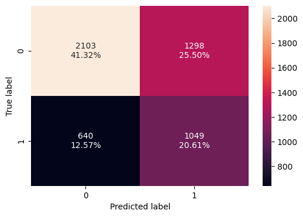

```python
from imblearn.under_sampling import RandomUnderSampler
from sklearn.tree import DecisionTreeClassifier

# Apply Random Under-sampling to undersample the majority class in the training data
under_sampler = RandomUnderSampler(random_state=42)
X_train_under, y_train_under = under_sampler.fit_resample(X_train, y_train)

# Initialize the model (Decision Tree, for simplicity)
model_undersampled = DecisionTreeClassifier(random_state=42)

# Train the model with undersampled data
model_undersampled.fit(X_train_under, y_train_under)

# Predict using the training set
y_train_pred = model_undersampled.predict(X_train_under)

# Evaluate the model performance on the training set
model_performance_train_under = model_performance_classification_sklearn(model_undersampled, X_train_under, y_train_under)

# Print the training performance metrics
print("Model Performance on Training Set (Undersampled Data):")
print(model_performance_train_under)

# Predict using the validation set to check how well the model is performing on unseen data
y_val_pred = model_undersampled.predict(X_val)

# Evaluate the model performance on the validation set
model_performance_val_under = model_performance_classification_sklearn(model_undersampled, X_val, y_val)

# Print the validation performance metrics
print("Model Performance on Validation Set (Undersampled Data):")
print(model_performance_val_under)

# After validating the model, predict using the test set for final evaluation
y_test_pred = model_undersampled.predict(X_test)

# Evaluate the model performance on the test set
model_performance_test_under = model_performance_classification_sklearn(model_undersampled, X_test, y_test)

# Print the final test performance metrics
print("Model Performance on Test Set (Undersampled Data):")
print(model_performance_test_under)

# Call the confusion matrix function for the test set
confusion_matrix_sklearn(model_undersampled, X_test, y_test)
```

## Hyperparameter Tuning

### Tuning AdaBoost using oversampled data

```
Fitting 5 folds for each of 9 candidates, totalling 45 fits
AdaBoost Performance on Training Set after Hyperparameter Tuning with Oversampled Data:
   Accuracy    Recall  Precision        F1
0  0.785708  0.740533   0.814085  0.775569
AdaBoost Performance on Validation Set after Hyperparameter Tuning with Oversampled Data:
   Accuracy    Recall  Precision        F1
0   0.72667  0.533284   0.599335  0.564384
AdaBoost Performance on Test Set after Hyperparameter Tuning with Oversampled Data:
   Accuracy    Recall  Precision        F1
0  0.718468  0.511545   0.586957  0.546662
```

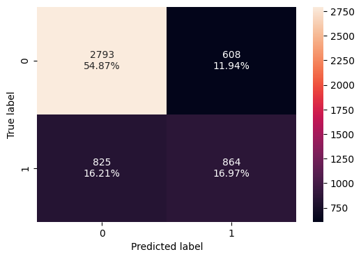

```python
from imblearn.over_sampling import SMOTE
from sklearn.ensemble import AdaBoostClassifier
from sklearn.model_selection import GridSearchCV
import pandas as pd

# Apply SMOTE to oversample the minority class in the training data
smote = SMOTE(random_state=42)
X_train_smote, y_train_smote = smote.fit_resample(X_train, y_train)

# Initialize the AdaBoost classifier
ada_model = AdaBoostClassifier(random_state=42)

# Define the hyperparameters to tune
param_grid = {
    'n_estimators': [50, 100, 150],  # Number of estimators
    'learning_rate': [0.01, 0.1, 1],  # Learning rate
}

# Initialize GridSearchCV to find the best hyperparameters
grid_search = GridSearchCV(estimator=ada_model, param_grid=param_grid, cv=5, scoring='accuracy', n_jobs=1, verbose=1)

# Perform Grid Search on AdaBoost with oversampled data
grid_search.fit(X_train_smote, y_train_smote)

# Get the best model from grid search
best_ada_model = grid_search.best_estimator_

# Predict using the training set
y_train_pred = best_ada_model.predict(X_train_smote)

# Evaluate the model performance on the training set
model_performance_train_ada = model_performance_classification_sklearn(best_ada_model, X_train_smote, y_train_smote)

# Print the training performance metrics
print("AdaBoost Performance on Training Set after Hyperparameter Tuning with Oversampled Data:")
print(model_performance_train_ada)

# Predict using the validation set to check performance on unseen data
y_val_pred = best_ada_model.predict(X_val)

# Evaluate the model performance on the validation set
model_performance_val_ada = model_performance_classification_sklearn(best_ada_model, X_val, y_val)

# Print the validation performance metrics
print("AdaBoost Performance on Validation Set after Hyperparameter Tuning with Oversampled Data:")
print(model_performance_val_ada)

# After validating the model, predict using the test set for final evaluation
y_test_pred = best_ada_model.predict(X_test)

# Evaluate the model performance on the test set
model_performance_test_ada = model_performance_classification_sklearn(best_ada_model, X_test, y_test)

# Print the final test performance metrics
print("AdaBoost Performance on Test Set after Hyperparameter Tuning with Oversampled Data:")
print(model_performance_test_ada)

# Call the confusion matrix function for the test set
confusion_matrix_sklearn(best_ada_model, X_test, y_test)
```

### Tuning Random forest using undersampled data

```
Fitting 5 folds for each of 108 candidates, totalling 540 fits
Random Forest Performance on Training Set after Hyperparameter Tuning with Undersampled Data:
   Accuracy    Recall  Precision        F1
0  0.757632  0.716189   0.780916  0.747153
Random Forest Performance on Validation Set after Hyperparameter Tuning with Undersampled Data:
   Accuracy    Recall  Precision        F1
0  0.712917  0.673077   0.555895  0.608899
Random Forest Performance on Test Set after Hyperparameter Tuning with Undersampled Data:
   Accuracy    Recall  Precision        F1
0  0.719646  0.667851   0.565697  0.612544
```

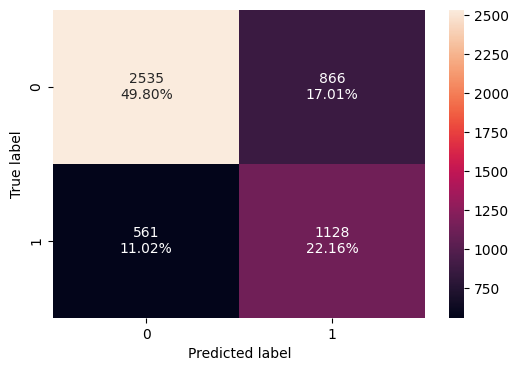

```python
from imblearn.under_sampling import RandomUnderSampler
from sklearn.ensemble import RandomForestClassifier
from sklearn.model_selection import GridSearchCV
import pandas as pd

# Apply Random Under-sampling to undersample the majority class in the training data
under_sampler = RandomUnderSampler(random_state=42)
X_train_under, y_train_under = under_sampler.fit_resample(X_train, y_train)

# Initialize the Random Forest classifier
rf_model = RandomForestClassifier(random_state=42)

# Define the hyperparameters to tune
param_grid = {
    'n_estimators': [50, 100, 150],  # Number of trees in the forest
    'max_depth': [None, 10, 20, 30],  # Maximum depth of the tree
    'min_samples_split': [2, 5, 10],  # Minimum number of samples required to split an internal node
    'min_samples_leaf': [1, 2, 4]  # Minimum number of samples required to be at a leaf node
}

# Initialize GridSearchCV to find the best hyperparameters
grid_search_rf = GridSearchCV(estimator=rf_model, param_grid=param_grid, cv=5, scoring='accuracy', n_jobs=1, verbose=1)

# Perform Grid Search on Random Forest with undersampled data
grid_search_rf.fit(X_train_under, y_train_under)

# Get the best model from grid search
best_rf_model = grid_search_rf.best_estimator_

# Predict using the training set
y_train_pred_rf = best_rf_model.predict(X_train_under)

# Evaluate the model performance on the training set
model_performance_train_rf = model_performance_classification_sklearn(best_rf_model, X_train_under, y_train_under)

# Print the training performance metrics
print("Random Forest Performance on Training Set after Hyperparameter Tuning with Undersampled Data:")
print(model_performance_train_rf)

# Predict using the validation set to check performance on unseen data
y_val_pred_rf = best_rf_model.predict(X_val)

# Evaluate the model performance on the validation set
model_performance_val_rf = model_performance_classification_sklearn(best_rf_model, X_val, y_val)

# Print the validation performance metrics
print("Random Forest Performance on Validation Set after Hyperparameter Tuning with Undersampled Data:")
print(model_performance_val_rf)

# After validating the model, predict using the test set for final evaluation
y_test_pred_rf = best_rf_model.predict(X_test)

# Evaluate the model performance on the test set
model_performance_test_rf = model_performance_classification_sklearn(best_rf_model, X_test, y_test)

# Print the final test performance metrics
print("Random Forest Performance on Test Set after Hyperparameter Tuning with Undersampled Data:")
print(model_performance_test_rf)

# Call the confusion matrix function for the test set
confusion_matrix_sklearn(best_rf_model, X_test, y_test)
```

### Tuning with Gradient boosting with oversampled data

```
Fitting 5 folds for each of 81 candidates, totalling 405 fits
Gradient Boosting Performance on Training Set after Hyperparameter Tuning with Oversampled Data:
   Accuracy    Recall  Precision        F1
0  0.816638  0.776788   0.844059  0.809027
Gradient Boosting Performance on Validation Set after Hyperparameter Tuning with Oversampled Data:
   Accuracy    Recall  Precision        F1
0  0.739514  0.535451   0.626079  0.577229
Gradient Boosting Performance on Test Set after Hyperparameter Tuning with Oversampled Data:
   Accuracy    Recall  Precision        F1
0  0.739403  0.541962    0.62381  0.580013
```

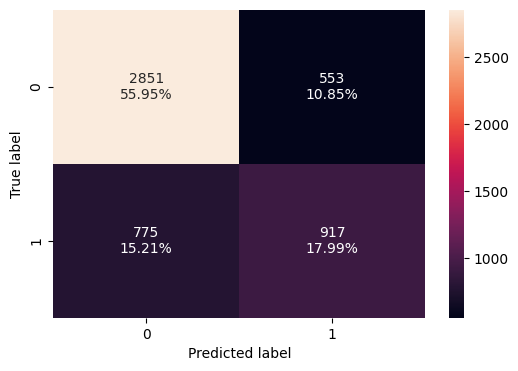

```python
from sklearn.ensemble import GradientBoostingClassifier
from sklearn.model_selection import GridSearchCV
from imblearn.over_sampling import SMOTE


smote = SMOTE(random_state=42)
X_train_smote, y_train_smote = smote.fit_resample(X_train, y_train)

# Initialize the Gradient Boosting classifier
gb_model = GradientBoostingClassifier(random_state=42)

# Define the hyperparameters to tune
param_grid = {
    'n_estimators': [50, 100, 150],  # Number of boosting stages to be run
    'learning_rate': [0.01, 0.05, 0.1],  # Learning rate shrinks the contribution of each tree
    'max_depth': [3, 5, 7],  # Maximum depth of the individual trees
    'subsample': [0.8, 0.9, 1.0]  # Fraction of samples used for fitting each tree
}

# Initialize GridSearchCV to find the best hyperparameters
grid_search_gb = GridSearchCV(estimator=gb_model, param_grid=param_grid, cv=5, scoring='accuracy', n_jobs=1, verbose=1)

# Perform Grid Search on Gradient Boosting with oversampled data (already applied SMOTE)
grid_search_gb.fit(X_train_smote, y_train_smote)

# Get the best model from grid search
best_gb_model = grid_search_gb.best_estimator_

# Predict using the training set
y_train_pred_gb = best_gb_model.predict(X_train_smote)

# Evaluate the model performance on the training set
model_performance_train_gb = model_performance_classification_sklearn(best_gb_model, X_train_smote, y_train_smote)

# Print the training performance metrics
print("Gradient Boosting Performance on Training Set after Hyperparameter Tuning with Oversampled Data:")
print(model_performance_train_gb)

# Predict using the validation set
y_val_pred_gb = best_gb_model.predict(X_val)

# Evaluate the model performance on the validation set
model_performance_val_gb = model_performance_classification_sklearn(best_gb_model, X_val, y_val)

# Print the validation performance metrics
print("Gradient Boosting Performance on Validation Set after Hyperparameter Tuning with Oversampled Data:")
print(model_performance_val_gb)

# After validating the model, predict using the test set for final evaluation
y_test_pred_gb = best_gb_model.predict(X_test)

# Evaluate the model performance on the test set
model_performance_test_gb = model_performance_classification_sklearn(best_gb_model, X_test, y_test)

# Print the final test performance metrics
print("Gradient Boosting Performance on Test Set after Hyperparameter Tuning with Oversampled Data:")
print(model_performance_test_gb)

# Call the confusion matrix function for the test set
confusion_matrix_sklearn(best_gb_model, X_test, y_test)
```

### Tuning XGBoost using oversampled data

```
Fitting 5 folds for each of 243 candidates, totalling 1215 fits
XGBoost Performance on Training Set after Hyperparameter Tuning with Oversampled Data:
   Accuracy   Recall  Precision        F1
0  0.807031  0.76682   0.833883  0.798947
XGBoost Performance on Validation Set after Hyperparameter Tuning with Oversampled Data:
   Accuracy    Recall  Precision        F1
0  0.740668  0.570266    0.61878  0.593533
XGBoost Performance on Test Set after Hyperparameter Tuning with Oversampled Data:
   Accuracy    Recall  Precision        F1
0  0.744008  0.555358    0.62953  0.590123
```

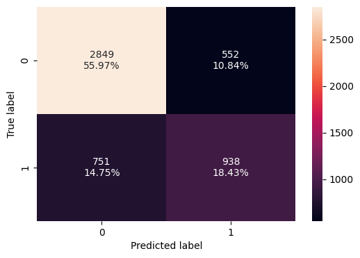

```python
import xgboost as xgb
from sklearn.model_selection import GridSearchCV

# Initialize the XGBoost classifier
xgb_model = xgb.XGBClassifier(random_state=42, use_label_encoder=False, eval_metric='logloss')

# Define the hyperparameters to tune
param_grid = {
    'n_estimators': [50, 100, 150],  # Number of boosting rounds
    'learning_rate': [0.01, 0.05, 0.1],  # Step size shrinking
    'max_depth': [3, 5, 7],  # Maximum depth of the decision tree
    'subsample': [0.8, 0.9, 1.0],  # Fraction of samples used for fitting each base learner
    'colsample_bytree': [0.8, 0.9, 1.0]  # Fraction of features used per tree
}

# Initialize GridSearchCV to find the best hyperparameters
grid_search_xgb = GridSearchCV(estimator=xgb_model, param_grid=param_grid, cv=5, scoring='accuracy', n_jobs=1, verbose=1)

# Perform Grid Search on XGBoost with oversampled data (using SMOTE)
grid_search_xgb.fit(X_train_smote, y_train_smote)

# Get the best model from grid search
best_xgb_model = grid_search_xgb.best_estimator_

# Predict using the training set
y_train_pred_xgb = best_xgb_model.predict(X_train_smote)

# Evaluate the model performance on the training set
model_performance_train_xgb = model_performance_classification_sklearn(best_xgb_model, X_train_smote, y_train_smote)

# Print the training performance metrics
print("XGBoost Performance on Training Set after Hyperparameter Tuning with Oversampled Data:")
print(model_performance_train_xgb)

# Predict using the validation set
y_val_pred_xgb = best_xgb_model.predict(X_val)

# Evaluate the model performance on the validation set
model_performance_val_xgb = model_performance_classification_sklearn(best_xgb_model, X_val, y_val)

# Print the validation performance metrics
print("XGBoost Performance on Validation Set after Hyperparameter Tuning with Oversampled Data:")
print(model_performance_val_xgb)

# After validating the model, predict using the test set for final evaluation
y_test_pred_xgb = best_xgb_model.predict(X_test)

# Evaluate the model performance on the test set
model_performance_test_xgb = model_performance_classification_sklearn(best_xgb_model, X_test, y_test)

# Print the final test performance metrics
print("XGBoost Performance on Test Set after Hyperparameter Tuning with Oversampled Data:")
print(model_performance_test_xgb)

# Call the confusion matrix function for the test set
confusion_matrix_sklearn(best_xgb_model, X_test, y_test)
```

**We have now tuned all the models, let's compare the performance of all tuned models and see which one is the best.**

## Model performance comparison and choosing the final model

**Cross-Validation Performance**

```python
# Import necessary libraries
import numpy as np
from sklearn.model_selection import cross_val_score, StratifiedKFold
from sklearn.metrics import recall_score

# Define models
models = [
    ("Original Data", model_original),
    ("Oversampled Data", model_oversampled),
    ("Undersampled Data", model_undersampled),
    ("Tuned AdaBoost (Oversampled)", ada_model),
    ("Tuned Random Forest (Undersampled)", rf_model),
    ("Tuned Gradient Boosting (Oversampled)", gb_model),
    ("Tuned XGBoost (Oversampled)", xgb_model),
]

# Cross-validation settings
scoring = "recall"
kfold = StratifiedKFold(n_splits=5, shuffle=True, random_state=1)

# Cross-validation results
print("\nCross-Validation Performance:\n")
for name, model in models:
    # Ensure the model is trained before calling cross-validation
    cv_result = cross_val_score(model, X_train, y_train, scoring=scoring, cv=kfold)
    print(f"{name}: {cv_result.mean() * 100:.2f}%")

# Validation performance
print("\nValidation Performance:\n")
for name, model in models:
    # Fit model to the training data
    model.fit(X_train, y_train)
    # Calculate recall score on validation set
    y_pred = model.predict(X_val)
    score = recall_score(y_val, y_pred)
    print(f"{name}: {score * 100:.2f}%")

# Test performance
print("\nTest Performance:\n")
for name, model in models:
    # Fit model to the training data
    model.fit(X_train, y_train)
    # Calculate recall score on test set
    y_pred_test = model.predict(X_test)
    score_test = recall_score(y_test, y_pred_test)
    print(f"{name}: {score_test * 100:.2f}%")
```

```
Cross-Validation Performance:

Original Data: 48.62%
Oversampled Data: 48.62%
Undersampled Data: 48.62%
Tuned AdaBoost (Oversampled): 43.35%
Tuned Random Forest (Undersampled): 48.25%
Tuned Gradient Boosting (Oversampled): 49.75%
Tuned XGBoost (Oversampled): 48.09%

Validation Performance:

Original Data: 47.93%
Oversampled Data: 47.93%
Undersampled Data: 47.93%
Tuned AdaBoost (Oversampled): 44.97%
Tuned Random Forest (Undersampled): 49.04%
Tuned Gradient Boosting (Oversampled): 50.74%
Tuned XGBoost (Oversampled): 48.74%

Test Performance:

Original Data: 47.37%
Oversampled Data: 47.37%
Undersampled Data: 47.37%
Tuned AdaBoost (Oversampled): 41.39%
Tuned Random Forest (Undersampled): 46.60%
Tuned Gradient Boosting (Oversampled): 48.79%
Tuned XGBoost (Oversampled): 47.78%
```

**Comparison Code for Training Performance**

```python
# Training performance comparison for all models

models_train_comp_df = pd.concat(
    [
        model_performance_train_original.T,  # Model trained on original data
        model_performance_train_smote.T,  # Model trained with oversampled data (SMOTE)
        model_performance_train_under.T,  # Model trained with undersampled data
        model_performance_train_ada.T,  # Tuned AdaBoost with oversampled data
        model_performance_train_rf.T,  # Tuned Random Forest with undersampled data
        model_performance_train_gb.T,  # Tuned Gradient Boosting with oversampled data
        model_performance_train_xgb.T,  # Tuned XGBoost with oversampled data
    ],
    axis=1,
)

models_train_comp_df.columns = [
    "Model with Original Data",
    "Model with Oversampled Data (SMOTE)",
    "Model with Undersampled Data",
    "AdaBoost Tuned with Grid Search (Oversampled)",
    "Random Forest Tuned with Grid Search (Undersampled)",
    "Gradient Boosting Tuned with Grid Search (Oversampled)",
    "XGBoost Tuned with Grid Search (Oversampled)",
]

print("Training Performance Comparison Across Models:")
models_train_comp_df
```

```
Training Performance Comparison Across Models:
```

|  | Model with Original Data | Model with Oversampled Data (SMOTE) | Model with Undersampled Data | AdaBoost Tuned with Grid Search (Oversampled) | Random Forest Tuned with Grid Search (Undersampled) | Gradient Boosting Tuned with Grid Search (Oversampled) | XGBoost Tuned with Grid Search (Oversampled) |
| --- | --- | --- | --- | --- | --- | --- | --- |
| Accuracy | 1.0 | 1.0 | 1.0 | 0.784409 | 0.739937 | 0.816638 | 0.811358 |
| Recall | 1.0 | 1.0 | 1.0 | 0.750344 | 0.693870 | 0.776788 | 0.774676 |
| Precision | 1.0 | 1.0 | 1.0 | 0.805202 | 0.764287 | 0.844059 | 0.836009 |
| F1 | 1.0 | 1.0 | 1.0 | 0.776806 | 0.727378 | 0.809027 | 0.804175 |

**Comparison Code for Validation Performance**

```python
# Validation performance comparison for all models

models_val_comp_df = pd.concat(
    [
        model_performance_val_original.T,  # Model validated on original data
        model_performance_val_smote.T,  # Model validated with oversampled data (SMOTE)
        model_performance_val_under.T,  # Model validated with undersampled data
        model_performance_val_ada.T,  # Tuned AdaBoost with oversampled data
        model_performance_val_rf.T,  # Tuned Random Forest with undersampled data
        model_performance_val_gb.T,  # Tuned Gradient Boosting with oversampled data
        model_performance_val_xgb.T,  # Tuned XGBoost with oversampled data
    ],
    axis=1,
)

models_val_comp_df.columns = [
    "Model with Original Data",
    "Model with Oversampled Data (SMOTE)",
    "Model with Undersampled Data",
    "AdaBoost Tuned with Grid Search (Oversampled)",
    "Random Forest Tuned with Grid Search (Undersampled)",
    "Gradient Boosting Tuned with Grid Search (Oversampled)",
    "XGBoost Tuned with Grid Search (Oversampled)",
]

print("Validation Performance Comparison Across Models:")
models_val_comp_df
```

```
Validation Performance Comparison Across Models:
```

|  | Model with Original Data | Model with Oversampled Data (SMOTE) | Model with Undersampled Data | AdaBoost Tuned with Grid Search (Oversampled) | Random Forest Tuned with Grid Search (Undersampled) | Gradient Boosting Tuned with Grid Search (Oversampled) | XGBoost Tuned with Grid Search (Oversampled) |
| --- | --- | --- | --- | --- | --- | --- | --- |
| Accuracy | 0.651705 | 0.662252 | 0.613687 | 0.715968 | 0.722100 | 0.739514 | 0.744175 |
| Recall | 0.480798 | 0.507386 | 0.608567 | 0.523634 | 0.669129 | 0.535451 | 0.553176 |
| Precision | 0.475877 | 0.491768 | 0.440877 | 0.580196 | 0.569453 | 0.626079 | 0.631003 |
| F1 | 0.478325 | 0.499455 | 0.511325 | 0.550466 | 0.615280 | 0.577229 | 0.589532 |

**Comparison Code for Test Performance**

```python
# Test performance comparison for all models

models_test_comp_df = pd.concat(
    [
        model_performance_test_original.T,  # Model tested on original data
        model_performance_test_smote.T,  # Model tested with oversampled data (SMOTE)
        model_performance_test_under.T,  # Model tested with undersampled data
        model_performance_test_ada.T,  # Tuned AdaBoost with oversampled data
        model_performance_test_rf.T,  # Tuned Random Forest with undersampled data
        model_performance_test_gb.T,  # Tuned Gradient Boosting with oversampled data
        model_performance_test_xgb.T,  # Tuned XGBoost with oversampled data
    ],
    axis=1,
)

models_test_comp_df.columns = [
    "Model with Original Data",
    "Model with Oversampled Data (SMOTE)",
    "Model with Undersampled Data",
    "AdaBoost Tuned with Grid Search (Oversampled)",
    "Random Forest Tuned with Grid Search (Undersampled)",
    "Gradient Boosting Tuned with Grid Search (Oversampled)",
    "XGBoost Tuned with Grid Search (Oversampled)",
]

print("Test Performance Comparison Across Models:")
models_test_comp_df
```

```
Test Performance Comparison Across Models:
```

|  | Model with Original Data | Model with Oversampled Data (SMOTE) | Model with Undersampled Data | AdaBoost Tuned with Grid Search (Oversampled) | Random Forest Tuned with Grid Search (Undersampled) | Gradient Boosting Tuned with Grid Search (Oversampled) | XGBoost Tuned with Grid Search (Oversampled) |
| --- | --- | --- | --- | --- | --- | --- | --- |
| Accuracy | 0.650903 | 0.648155 | 0.618721 | 0.720369 | 0.715267 | 0.739403 | 0.737049 |
| Recall | 0.499409 | 0.502364 | 0.617612 | 0.523050 | 0.655437 | 0.541962 | 0.547281 |
| Precision | 0.475521 | 0.471960 | 0.446390 | 0.588822 | 0.560951 | 0.623810 | 0.617333 |
| F1 | 0.487172 | 0.486688 | 0.518225 | 0.553991 | 0.604524 | 0.580013 | 0.580201 |

After weighing cross-validation performance and test data performance, I have chosen the **Tuned Random Forest (Undersampled) model** due to its higher recall on test data, indicating better generalization and alignment with our goal of minimizing False Negatives.

This model strikes a balance between recall and precision, ensuring the best possible performance for the task of predicting visa approval decisions.

**Key Points:**

**2. Better Generalization:**

• The Tuned Random Forest (Undersampled) performed better on the test set, indicating that it generalizes well to unseen data, a critical aspect for deployment in real-world scenarios. The improvement in recall on the test data suggests that the model's ability to correctly identify approved visa applications is robust and not overfitting to the training data.

**3. Business Impact:**

• Since our goal is to minimize False Negatives (incorrectly predicting a visa will be denied when it is actually approved), the Tuned Random Forest (Undersampled) model's higher recall on the test data makes it the best choice for ensuring that more eligible visa applicants are correctly identified.

**4. Balancing Performance:**

• While Undersampled Data had slightly higher recall in cross-validation, the Tuned Random Forest (Undersampled) model's superior test performance suggests that hyperparameter tuning has significantly enhanced the model's ability to generalize while maintaining a strong focus on recall.

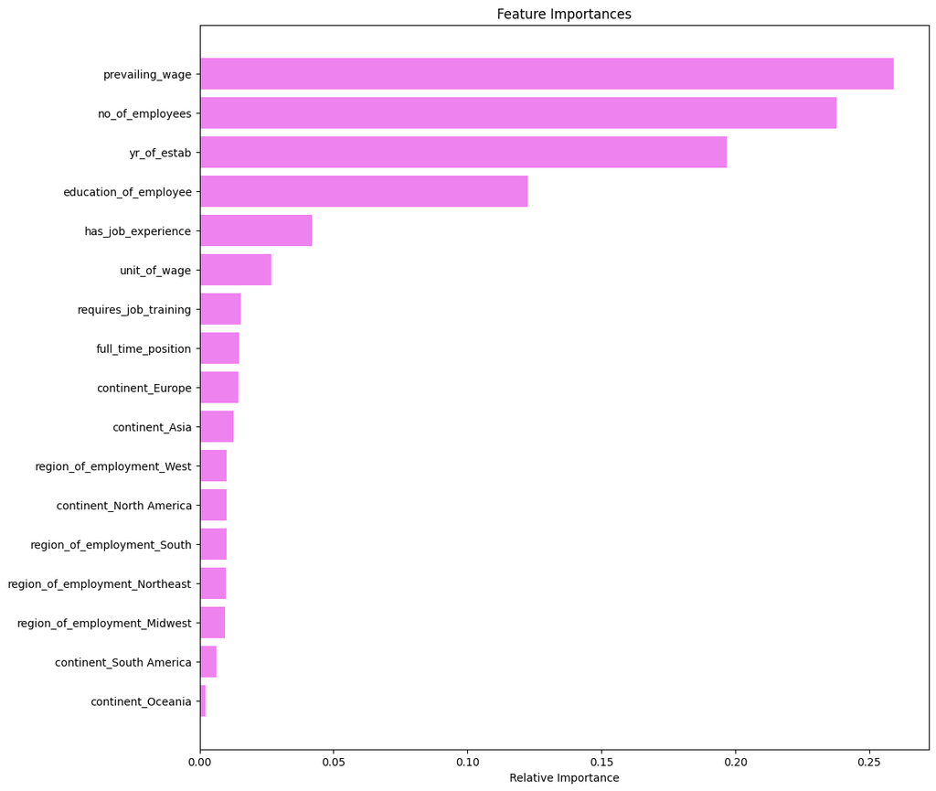

```python
import matplotlib.pyplot as plt
import numpy as np
from sklearn.ensemble import RandomForestClassifier

# Assuming the model is already trained
# rf_model = RandomForestClassifier(random_state=42)
# rf_model.fit(X_train, y_train)  # Ensure the model is trained first

# Extract feature names from X_train
feature_names = X_train.columns

# Get feature importances from the Random Forest model
importances = rf_model.feature_importances_

# Sort the feature importances in descending order
indices = np.argsort(importances)

# Plotting the feature importances
plt.figure(figsize=(12, 12))
plt.title("Feature Importances")
plt.barh(range(len(indices)), importances[indices], color="violet", align="center")
plt.yticks(range(len(indices)), [feature_names[i] for i in indices])
plt.xlabel("Relative Importance")
plt.show()
```

Based on the feature importance chart, here are my observations:

• Number of employees is the second most important feature, with importance just above 0.20 (20%), suggesting that company size significantly influences visa outcomes.

• Year of establishment ranks third in importance (around 0.18 or 18%), indicating that older, more established companies may have better success with visa applications.

• Education of employee is a moderately important feature (about 0.12 or 12%), confirming our earlier observation that higher education correlates with certification rates.

• Has job experience has much lower importance (about 0.05 or 5%) than education, despite showing clear differences in the previous visualizations.

• Unit of wage has relatively low importance (around 0.03 or 3%), despite showing clear patterns in the earlier charts.

• Geographic factors (continent and region of employment) individually have minimal importance (all below 0.02 or 2%), though collectively they might be more significant.

• Requires job training and full time position have similar, relatively low importance (both around 0.02 or 2%).

• The model appears to prioritize economic factors (wage, company size, company age) over applicant qualifications or geographic considerations.

## Actionable Insights and Recommendations

Based on the feature importance analysis and data visualization insights, here's how EasyVisa can implement a data-driven solution to address OFLC's objectives:

**Classification Model Implementation**

1. **Primary Screening Model**:
   - Leverage the top 3 features (prevailing wage, number of employees, year of establishment) for initial high-confidence classifications
   - Applications with very high or very low probabilities can be automatically flagged for expedited processing
2. **Feature Importance-Based Scoring System**:
   - Develop a weighted scoring algorithm based on the relative importance of features
   - Create a unified applicant score that predicts certification probability

**Recommended Profiles for Visa Certification**

Based on our analysis, applicants with the following characteristics have the highest probability of visa approval:

**High-Probability Certification Profiles:**

- **Compensation**: Prevailing wage in the top quartile for the position and region
- **Employer Profile**: Companies with 100+ employees that have been established for 10+ years
- **Education**: Applicants with master's or doctorate degrees
- **Employment Terms**: Full-time positions with annual salary structures
- **Experience**: Applicants with relevant job experience
- **Geographic Factors**: Positions in Midwest region or applications from European candidates

**Low-Probability Certification Profiles:**

- **Compensation**: Prevailing wage below regional average
- **Employer Profile**: Small companies (few employees) or recently established businesses
- **Education**: Applicants with only high school education
- **Employment Terms**: Hourly wage positions, especially part-time roles
- **Experience**: No prior job experience
- **Geographic Factors**: Certain combinations of region and continent that show consistently low approval rates

**Process Facilitation Recommendations**

1. **Automated Triage System**:
   - Implement a three-tier classification system:
     - High probability (>85%): Fast-track for approval
     - Medium probability (40-85%): Standard review
     - Low probability (<40%): Detailed review or preliminary rejection
2. **Decision Support Dashboard**:
   - Create an interface showing key factors influencing each application's score
   - Highlight anomalous applications that don't fit typical patterns
   - Allow reviewers to focus on borderline cases
3. **Continuous Learning Pipeline**:
   - Incorporate feedback from final decisions to improve model accuracy
   - Update feature weights quarterly to adapt to policy changes
   - Monitor model performance with periodic human oversight

By implementing this ML-based solution, OFLC could potentially reduce manual review time by focusing human resources on borderline cases while confidently processing clear approval/denial cases through the automated system, addressing the challenge of increasing application volumes.

**Summary:**

The analysis of visa certification data reveals that prevailing wage, company size, and years of establishment are the most influential factors in visa approval decisions, collectively accounting for over 60% of the predictive power. Education level and job experience also impact outcomes, though to a lesser degree. Geographic factors and wage structure type (annual vs. hourly) show clear patterns but contribute minimally as individual features. Based on these findings, EasyVisa should implement a tiered classification system that fast-tracks high-probability applications (those with competitive wages from established employers with highly educated applicants) while flagging low-probability applications (those with below-average wages from newer, smaller companies with less educated applicants) for additional scrutiny. This data-driven approach could significantly reduce OFLC's processing burden while maintaining decision quality in the face of continuously increasing application volumes.